# deovad_dual_cycle_etl

```python
import sys
import warnings
import time
import pandas as pd
import numpy as np
import seaborn as sns
import matplotlib.pyplot as plt
import logging
import datetime
import requests

import os
from sqlalchemy import create_engine, Column, MetaData
from clickhouse_sqlalchemy import get_declarative_base, types, engines
import cx_Oracle
from tqdm import tqdm
```

```python
# cx_Oracle.init_oracle_client(lib_dir='C:/workspace/instantclient_19_19')  # OS windows # OS 리눅스

warnings.filterwarnings('ignore')

# oracle_ip = 'klnet/zpdldpfspt1234@172.24.200.233:1521/orcl'

# clickhouse conn url
# clickhouse_ip = 'clickhouse://default:klnet2022!@110.45.218.71:8123/20001_DB'
clickhouse_ip = 'clickhouse://default:klnet2022!@110.45.218.243:8123/20001_DB'

Click_House_Engine = create_engine(clickhouse_ip)

metadata = MetaData(bind=Click_House_Engine)

Base = get_declarative_base(metadata=metadata)
```

```python
connection = cx_Oracle.connect(oracle_ip,encoding='utf8')
```

dbeaver에서 먼저 sql 테스트 적용 후 일부만 가져와야 할 듯  
timeoutError남

일자 컬럼: IN_OUT_TIME_DT

```python
cl_sql = """
WITH PORT_CODE AS (
	SELECT DISTINCT
		CHEONG_CODE
		,PORT
	FROM 20001_DB.TERMINAL_INFO_TBL tit
),
DDTV2 AS (
	SELECT DISTINCT PORT_CODE.PORT, ddtv.CALLSIGN, ddtv.ATA, ddtv.ATD
	FROM PORT_CODE
	JOIN 20001_DB.DEOCOS_DEOVAD_TBL_V3 ddtv
	ON ddtv.PRTC = PORT_CODE.CHEONG_CODE
)
SELECT vtwclav.*, DDTV2.ATA, DDTV2.ATD
FROM 20001_DB.VESSEL_TERMINAL_WHARF_CNTR_LOAD_AMOUNT_V2 vtwclav
JOIN DDTV2
ON vtwclav.PORT_CODE = DDTV2.PORT
AND vtwclav.CALLSIGN =  DDTV2.CALLSIGN
WHERE vtwclav.IN_OUT_TIME_DT BETWEEN DDTV2.ATA AND DDTV2.ATD
"""
cl_df = pd.read_sql(cl_sql, Click_House_Engine)
```

[output not shown]

[output cut: 490 more lines]

[output not shown]

### 듀얼 사이클 프로세스 적용한 양적하 업무 기록 유무 확인

**deovad_tp SQL**

WITH PORT_CODE AS (  
SELECT DISTINCT  
CHEONG_CODE  
,PORT  
FROM 20001_DB.TERMINAL_INFO_TBL tit  
),  
DDTV2 AS (  
SELECT DISTINCT PORT_CODE.PORT, ddtv.CALLSIGN, ddtv.ATA, ddtv.ATD  
FROM PORT_CODE  
JOIN 20001_DB.DEOCOS_DEOVAD_TBL_V3 ddtv  
ON ddtv.PRTC = PORT_CODE.CHEONG_CODE  
)  
SELECT vtwclav.*, DDTV2.ATA, DDTV2.ATD  
FROM 20001_DB.VESSEL_TERMINAL_WHARF_CNTR_LOAD_AMOUNT_V2 vtwclav  
JOIN DDTV2  
ON vtwclav.PORT_CODE = DDTV2.PORT  
AND vtwclav.CALLSIGN = DDTV2.CALLSIGN  
WHERE vtwclav.IN_OUT_TIME_DT BETWEEN DDTV2.ATA AND DDTV2.ATD

```python
deovad_tp = pd.read_csv('../test_data/DEOVAD_TP.csv')
deovad_tp
```

|  | DOC_ID | VESSEL_CODE | TERMINAL | PORT_CODE | BERTH | CONTAINER_NO | DANGER_UN | DANGER_IMDG | STOWAGE_LOCATION | TYPE_SIZE | ... | NATION | NATION_NM | VESSEL_TYPE | TOTAL_TON | LEN | WIDTH | DEPTH | SAMPLING_NUMBER | ATA | ATD |
| --- | --- | --- | --- | --- | --- | --- | --- | --- | --- | --- | --- | --- | --- | --- | --- | --- | --- | --- | --- | --- | --- |
| 0 | 268504777 | PVIC | UDITC | KRUSN | 1G | CRSU1218396 | NaN | NaN | 230684 | 2200 | ... | KR | KOREA | 컨테이너선 | 9923.0 | 148.2 | 22.7 | 11.2 | 0.389392 | 2019-10-04 08:15:00 | 2019-10-04 15:00:00 |
| 1 | 268504777 | PVIC | UDITC | KRUSN | 1G | CRSU1261577 | NaN | NaN | 230286 | 2200 | ... | KR | KOREA | 컨테이너선 | 9923.0 | 148.2 | 22.7 | 11.2 | 0.649381 | 2019-10-04 08:15:00 | 2019-10-04 15:00:00 |
| 2 | 268504777 | PVIC | UDITC | KRUSN | 1G | HJMU2025968 | NaN | NaN | 210382 | 2200 | ... | KR | KOREA | 컨테이너선 | 9923.0 | 148.2 | 22.7 | 11.2 | 0.651391 | 2019-10-04 08:15:00 | 2019-10-04 15:00:00 |
| 3 | 268504777 | PVIC | UDITC | KRUSN | 1G | PCLU2040964 | NaN | NaN | 210484 | 2200 | ... | KR | KOREA | 컨테이너선 | 9923.0 | 148.2 | 22.7 | 11.2 | 0.479507 | 2019-10-04 08:15:00 | 2019-10-04 15:00:00 |
| 4 | 268504777 | PVIC | UDITC | KRUSN | 1G | PCLU2041600 | NaN | NaN | 290182 | 2200 | ... | KR | KOREA | 컨테이너선 | 9923.0 | 148.2 | 22.7 | 11.2 | 0.617465 | 2019-10-04 08:15:00 | 2019-10-04 15:00:00 |
| ... | ... | ... | ... | ... | ... | ... | ... | ... | ... | ... | ... | ... | ... | ... | ... | ... | ... | ... | ... | ... | ... |
| 8020560 | 342239211 | YLJG | SNCTC | KRINC | 6A | RFCU4075929 | NaN | NaN | 0120184 | 4510 | ... | CN | CHINA | 부선 | 5250.0 | 20.0 | 20.0 | 9.0 | 0.662056 | 2021-11-07 16:20:00 | 2021-11-11 02:23:00 |
| 8020561 | 342239452 | YLJG | SNCTC | KRINC | 6A | FCIU9939330 | NaN | NaN | 0120284 | 4510 | ... | CN | CHINA | 부선 | 5250.0 | 20.0 | 20.0 | 9.0 | 0.740724 | 2021-11-07 16:20:00 | 2021-11-11 02:23:00 |
| 8020562 | 342239532 | YLJG | SNCTC | KRINC | 5A | TGBU8844810 | NaN | NaN | 0120884 | 4510 | ... | CN | CHINA | 부선 | 5250.0 | 20.0 | 20.0 | 9.0 | 0.093369 | 2021-11-07 16:20:00 | 2021-11-11 02:23:00 |
| 8020563 | 342239536 | YLJG | SNCTC | KRINC | 5A | CBHU9088550 | NaN | NaN | 0120484 | 4510 | ... | CN | CHINA | 부선 | 5250.0 | 20.0 | 20.0 | 9.0 | 0.944348 | 2021-11-07 16:20:00 | 2021-11-11 02:23:00 |
| 8020564 | 342239537 | YLJG | SNCTC | KRINC | 5A | TGCU0001650 | NaN | NaN | 0120684 | 4510 | ... | CN | CHINA | 부선 | 5250.0 | 20.0 | 20.0 | 9.0 | 0.521823 | 2021-11-07 16:20:00 | 2021-11-11 02:23:00 |

8020565 rows × 30 columns

DEOVAD_TP GROUP BY (TERMINAL, PORT_CODE, CALLSIGN, ATA, ATD)  
*HAVING I_CNT > 1 AND E_CNT > 1*

- I_CNT와 E_CNT가 둘 다 발생한 경우만 센 것

  WITH PORT_CODE AS (  
  SELECT DISTINCT

  ```
   CHEONG_CODE
   ,PORT
  ```

  FROM 20001_DB.TERMINAL_INFO_TBL tit  
  ),  
  DDTV2 AS (  
  SELECT DISTINCT PORT_CODE.PORT, ddtv.CALLSIGN, ddtv.ATA, ddtv.ATD  
  FROM PORT_CODE  
  JOIN 20001_DB.DEOCOS_DEOVAD_TBL_V3 ddtv  
  ON ddtv.PRTC = PORT_CODE.CHEONG_CODE  
  ),  
  DDTV_TP AS (  
  SELECT vtwclav.*, DDTV2.ATA, DDTV2.ATD  
  FROM 20001_DB.VESSEL_TERMINAL_WHARF_CNTR_LOAD_AMOUNT_V2 vtwclav  
  JOIN DDTV2  
  ON vtwclav.PORT_CODE = DDTV2.PORT  
  AND vtwclav.CALLSIGN = DDTV2.CALLSIGN  
  WHERE vtwclav.IN_OUT_TIME_DT BETWEEN DDTV2.ATA AND DDTV2.ATD  
  )  
  SELECT TERMINAL, PORT_CODE, BERTH, CALLSIGN, ATA, ATD  
  ,SUM(CASE WHEN IE_TYPE = 'I' THEN 1 ELSE 0 END) AS I_CNT  
  ,SUM(CASE WHEN IE_TYPE = 'E' THEN 1 ELSE 0 END) AS E_CNT  
  FROM DDTV_TP  
  GROUP BY TERMINAL, PORT_CODE, BERTH, CALLSIGN, ATA, ATD  
  HAVING I_CNT > 1 AND E_CNT >1

```python
ie_cnt = pd.read_csv('../test_data/DEOVAD_IE_FIND.csv')
ie_cnt
```

|  | TERMINAL | PORT_CODE | CALLSIGN | ATA | ATD | I_CNT | E_CNT |
| --- | --- | --- | --- | --- | --- | --- | --- |
| 0 | PECTC | KRPUS | D5QW9 | 2019-05-19 20:35:00 | 2019-05-20 05:58:00 | 120 | 138 |
| 1 | PECTC | KRPUS | V2HD9 | 2020-04-04 03:15:00 | 2020-04-04 15:08:00 | 187 | 194 |
| 2 | E1CTC | KRINC | DSRI4 | 2021-12-04 23:40:00 | 2021-12-05 21:45:00 | 549 | 434 |
| 3 | PNCTC | KRPTK | D5MO4 | 2021-10-01 12:48:00 | 2021-10-02 00:51:00 | 282 | 288 |
| 4 | SNCTC | KRINC | V7IQ4 | 2019-02-18 15:55:00 | 2019-02-19 04:25:00 | 320 | 792 |
| ... | ... | ... | ... | ... | ... | ... | ... |
| 6536 | BCTOC | KRPUS | H8KJ | 2020-04-29 22:06:00 | 2020-04-30 22:00:00 | 716 | 628 |
| 6537 | HJITC | KRINC | D5ST2 | 2021-04-26 17:00:00 | 2021-04-27 07:05:00 | 415 | 255 |
| 6538 | PNDKC | KRPUS | DSQX2 | 2021-06-20 12:10:00 | 2021-06-20 16:50:00 | 41 | 30 |
| 6539 | UDITC | KRUSN | DSRI4 | 2019-02-03 01:45:00 | 2019-02-03 05:35:00 | 82 | 106 |
| 6540 | E1CTC | KRINC | VRRO7 | 2021-03-01 18:12:00 | 2021-03-02 00:05:00 | 160 | 73 |

6541 rows × 7 columns

DEOVAD_TP GROUP BY (TERMINAL, PORT_CODE, BERTH, CALLSIGN, ATA, ATD)

```python
ie_cnt_with_berth = pd.read_csv('../test_data/DEOVAD_IE_FIND_WITH_BERTH.csv')
ie_cnt_with_berth
```

|  | TERMINAL | PORT_CODE | BERTH | CALLSIGN | ATA | ATD | I_CNT | E_CNT |
| --- | --- | --- | --- | --- | --- | --- | --- | --- |
| 0 | PECTC | KRPUS | 8C | D7EE | 2021-11-27 22:05:00 | 2021-11-28 22:53:00 | 51 | 5 |
| 1 | PECTC | KRPUS | 1G | HO3256 | 2019-11-02 22:15:00 | 2019-11-04 05:54:00 | 20 | 24 |
| 2 | BICTC | KRPUS | 4C | D7CC | 2021-06-05 03:10:00 | 2021-06-05 18:29:00 | 20 | 4 |
| 3 | BICTC | KRPUS | 7I | D5QP3 | 2020-07-11 02:50:00 | 2020-07-11 09:58:00 | 7 | 5 |
| 4 | BCTOC | KRPUS | 1G | D7KC | 2020-07-28 19:35:00 | 2020-07-29 11:10:00 | 16 | 10 |
| ... | ... | ... | ... | ... | ... | ... | ... | ... |
| 45971 | BICTC | KRPUS | DL | D7BD | 2020-05-12 06:40:00 | 2020-05-13 04:06:00 | 12 | 2 |
| 45972 | BICTC | KRPUS | 4H | D5QP3 | 2020-08-06 09:10:00 | 2020-08-07 03:57:00 | 4 | 6 |
| 45973 | BICTC | KRPUS | 3D | DSRJ5 | 2020-11-14 19:35:00 | 2020-11-15 16:10:00 | 9 | 13 |
| 45974 | DPCTC | KRPUS | 2E | 9V2444 | 2019-05-07 23:14:00 | 2019-05-08 10:00:00 | 8 | 40 |
| 45975 | DPCTC | KRPUS | 1G | 3FQI9 | 2021-01-11 16:35:00 | 2021-01-13 07:51:00 | 45 | 9 |

45976 rows × 8 columns

```python
ie_cnt_with_berth.isna().sum()
```

```
TERMINAL        0
PORT_CODE       0
BERTH        1578
CALLSIGN        0
ATA             0
ATD             0
I_CNT           0
E_CNT           0
dtype: int64
```

- 접안된 항만>터미널>선석>선박별로 **ATA~ATD 시간 안에** 양적하 작업이 함께(I_CNT&E_CNT>1) 일어난 건 수는 45,976건

```python
# ie_cnt_with_berth group by 기준으로 필터링한 deovad_tp
# join by :: ['TERMINAL', 'PORT_CODE', 'BERTH', 'CALLSIGN', 'ATA', 'ATD']
filtered_deovad_tp_with_berth = pd.merge(deovad_tp, ie_cnt_with_berth, on=list(ie_cnt_with_berth.columns)[:-2])
filtered_deovad_tp_with_berth.shape
```

```
(5039884, 32)
```

```python
tempp = pd.merge(deovad_tp, ie_cnt_with_berth, on=list(ie_cnt_with_berth.columns)[:-2], how='left')
tempp.shape ## tempp:: 양적하작업이 함께 일어나지 않은 경우도 포함
```

[output not shown]

```python
filtered_deovad_tp_with_berth.loc[:20, ['TERMINAL', 'PORT_CODE', 'BERTH', 'CALLSIGN', 'ATA', 'ATD', 'IE_TYPE', 'IN_OUT_TIME_DT']]
```

|  | TERMINAL | PORT_CODE | BERTH | CALLSIGN | ATA | ATD | IE_TYPE | IN_OUT_TIME_DT |
| --- | --- | --- | --- | --- | --- | --- | --- | --- |
| 0 | PCTCC | KRPTK | 2C | V7UX8 | 2019-10-04 21:05:00 | 2019-10-05 05:36:00 | I | 2019-10-04 21:48:00 |
| 1 | PCTCC | KRPTK | 2C | V7UX8 | 2019-10-04 21:05:00 | 2019-10-05 05:36:00 | I | 2019-10-04 22:11:00 |
| 2 | PCTCC | KRPTK | 2C | V7UX8 | 2019-10-04 21:05:00 | 2019-10-05 05:36:00 | E | 2019-10-05 01:58:00 |
| 3 | PCTCC | KRPTK | 2C | V7UX8 | 2019-10-04 21:05:00 | 2019-10-05 05:36:00 | E | 2019-10-05 01:55:00 |
| 4 | PCTCC | KRPTK | 2C | V7UX8 | 2019-10-04 21:05:00 | 2019-10-05 05:36:00 | E | 2019-10-05 01:59:00 |
| 5 | PCTCC | KRPTK | 2C | V7UX8 | 2019-10-04 21:05:00 | 2019-10-05 05:36:00 | E | 2019-10-05 02:05:00 |
| 6 | PCTCC | KRPTK | 2C | V7UX8 | 2019-10-04 21:05:00 | 2019-10-05 05:36:00 | E | 2019-10-05 02:25:00 |
| 7 | PCTCC | KRPTK | 2C | V7UX8 | 2019-10-04 21:05:00 | 2019-10-05 05:36:00 | E | 2019-10-05 02:25:00 |
| 8 | PCTCC | KRPTK | 2C | V7UX8 | 2019-10-04 21:05:00 | 2019-10-05 05:36:00 | E | 2019-10-05 01:59:00 |
| 9 | PCTCC | KRPTK | 2C | V7UX8 | 2019-10-04 21:05:00 | 2019-10-05 05:36:00 | E | 2019-10-05 02:05:00 |
| 10 | PCTCC | KRPTK | 2C | V7UX8 | 2019-10-04 21:05:00 | 2019-10-05 05:36:00 | E | 2019-10-05 01:58:00 |
| 11 | PCTCC | KRPTK | 2C | V7UX8 | 2019-10-04 21:05:00 | 2019-10-05 05:36:00 | E | 2019-10-05 01:55:00 |
| 12 | PCTCC | KRPTK | 2C | V7UX8 | 2019-10-04 21:05:00 | 2019-10-05 05:36:00 | E | 2019-10-05 01:59:00 |
| 13 | PCTCC | KRPTK | 2C | V7UX8 | 2019-10-04 21:05:00 | 2019-10-05 05:36:00 | E | 2019-10-05 02:05:00 |
| 14 | PCTCC | KRPTK | 2C | V7UX8 | 2019-10-04 21:05:00 | 2019-10-05 05:36:00 | E | 2019-10-05 02:25:00 |
| 15 | PCTCC | KRPTK | 2C | V7UX8 | 2019-10-04 21:05:00 | 2019-10-05 05:36:00 | E | 2019-10-05 02:25:00 |
| 16 | PCTCC | KRPTK | 2C | V7UX8 | 2019-10-04 21:05:00 | 2019-10-05 05:36:00 | E | 2019-10-05 01:59:00 |
| 17 | PCTCC | KRPTK | 2C | V7UX8 | 2019-10-04 21:05:00 | 2019-10-05 05:36:00 | E | 2019-10-05 02:05:00 |
| 18 | PCTCC | KRPTK | 2C | V7UX8 | 2019-10-04 21:05:00 | 2019-10-05 05:36:00 | I | 2019-10-04 21:48:00 |
| 19 | PCTCC | KRPTK | 2C | V7UX8 | 2019-10-04 21:05:00 | 2019-10-05 05:36:00 | I | 2019-10-04 22:11:00 |
| 20 | PNITC | KRPUS | 13 | 3EUJ | 2019-10-04 02:15:00 | 2019-10-04 22:45:00 | I | 2019-10-04 03:25:00 |

```python
deovad_tp.shape
```

[output not shown]

```python
# ie_cnt group by 기준으로 필터링한 deovad_tp
filtered_deovad_tp = pd.merge(deovad_tp, ie_cnt, on=list(ie_cnt.columns)[:-2])
filtered_deovad_tp.shape
```

```
(8009948, 32)
```

```python
cnt = filtered_deovad_tp_with_berth.groupby(['TERMINAL', 'PORT_CODE', 'BERTH', 'CALLSIGN', 'ATA', 'ATD', 'IE_TYPE']).size()
cnt
```

```
TERMINAL  PORT_CODE  BERTH  CALLSIGN  ATA                  ATD                  IE_TYPE
BCTOC     KRPUS      1A     3ECW9     2019-12-30 14:45:00  2019-12-31 05:54:00  E          26
                                                                                I          22
                                      2020-01-28 09:22:00  2020-01-29 05:25:00  E          16
                                                                                I          30
                                      2020-03-23 17:40:00  2020-03-24 17:00:00  E           3
                                                                                           ..
SNCTC     KRINC      X1     S6DT5     2020-04-15 17:54:00  2020-04-16 07:24:00  I           3
                            S6DT6     2021-01-17 08:30:00  2021-01-17 22:00:00  E           4
                                                                                I           2
                                      2021-08-08 06:55:00  2021-08-09 03:05:00  E           6
                                                                                I           2
Length: 88796, dtype: int64
```

```python
cntr_cnt = filtered_deovad_tp_with_berth.groupby(['TERMINAL', 'PORT_CODE', 'BERTH', 'CALLSIGN', 'ATA', 'ATD', 'IE_TYPE']).agg({'CONTAINER_NO': 'count'})
cntr_cnt
```

| TERMINAL | PORT_CODE | BERTH | CALLSIGN | ATA | ATD | IE_TYPE | CONTAINER_NO |
| --- | --- | --- | --- | --- | --- | --- | --- |
| BCTOC | KRPUS | 1A | 3ECW9 | 2019-12-30 14:45:00 | 2019-12-31 05:54:00 | E | 26 |
|  |  |  |  |  |  | I | 22 |
|  |  |  |  | 2020-01-28 09:22:00 | 2020-01-29 05:25:00 | E | 16 |
|  |  |  |  |  |  | I | 30 |
|  |  |  |  | 2020-03-23 17:40:00 | 2020-03-24 17:00:00 | E | 3 |
| ... | ... | ... | ... | ... | ... | ... | ... |
| SNCTC | KRINC | X1 | S6DT5 | 2020-04-15 17:54:00 | 2020-04-16 07:24:00 | I | 3 |
|  |  |  | S6DT6 | 2021-01-17 08:30:00 | 2021-01-17 22:00:00 | E | 4 |
|  |  |  |  |  |  | I | 2 |
|  |  |  |  | 2021-08-08 06:55:00 | 2021-08-09 03:05:00 | E | 6 |
|  |  |  |  |  |  | I | 2 |

88796 rows × 1 columns

```python
np.allclose(cnt.values, cntr_cnt.values[:,0])
```

```
True
```

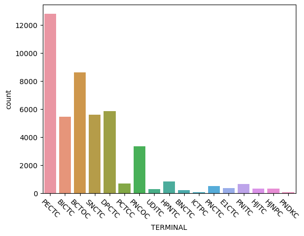

```python
plt.xticks(rotation=-45)
sns.countplot(x='TERMINAL', data=ie_cnt_with_berth)
```

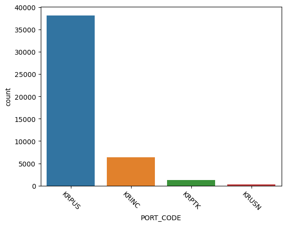

```python
plt.xticks(rotation=-45)
sns.countplot(x='PORT_CODE', data=ie_cnt_with_berth)
```

- 부산 > 인천 > 평택/당진 > 울산

```python
berth_key = ['TERMINAL', 'PORT_CODE', 'BERTH', 'CALLSIGN', 'ATA', 'ATD']
```

```python
grby_berth = dict(list(filtered_deovad_tp_with_berth.groupby(berth_key)))
grby_berth_key = list(output.keys())
```

```python
tp_v = grby_berth_key[0]
tp_sample = deovad_tp.loc[np.where((deovad_tp[berth_key[0]]==tp_v[0]) & \
                       (deovad_tp[berth_key[1]]==tp_v[1]) & \
                       (deovad_tp[berth_key[2]]==tp_v[2]) & \
                       (deovad_tp[berth_key[3]]==tp_v[3]) & \
                       (deovad_tp[berth_key[4]]==tp_v[4]) & \
                       (deovad_tp[berth_key[5]]==tp_v[5]))[0],:] #.to_csv('../test_data/DEOVAD_DUAL_SAMPLE.csv', index=None)
tp_sample
```

|  | DOC_ID | VESSEL_CODE | TERMINAL | PORT_CODE | BERTH | CONTAINER_NO | DANGER_UN | DANGER_IMDG | STOWAGE_LOCATION | TYPE_SIZE | ... | NATION | NATION_NM | VESSEL_TYPE | TOTAL_TON | LEN | WIDTH | DEPTH | SAMPLING_NUMBER | ATA | ATD |
| --- | --- | --- | --- | --- | --- | --- | --- | --- | --- | --- | --- | --- | --- | --- | --- | --- | --- | --- | --- | --- | --- |
| 4363209 | 275633711 | KKPN | BCTOC | KRPUS | 1A | FFAU1065143 | NaN | NaN | 220986 | 4500 | ... | PA | PANAMA | 컨테이너선 | 28517.0 | 200.0 | 35.2 | 16.8 | 0.878649 | 2019-12-30 14:45:00 | 2019-12-31 05:54:00 |
| 4363213 | 275633715 | KKPN | BCTOC | KRPUS | 1A | DFSU7685060 | NaN | NaN | 220586 | 4500 | ... | PA | PANAMA | 컨테이너선 | 28517.0 | 200.0 | 35.2 | 16.8 | 0.228239 | 2019-12-30 14:45:00 | 2019-12-31 05:54:00 |
| 4363219 | 275634460 | KKPN | BCTOC | KRPUS | 1A | BMOU4759656 | NaN | NaN | 221382 | 4500 | ... | PA | PANAMA | 컨테이너선 | 28517.0 | 200.0 | 35.2 | 16.8 | 0.444881 | 2019-12-30 14:45:00 | 2019-12-31 05:54:00 |
| 4363227 | 275634473 | KKPN | BCTOC | KRPUS | 1A | CAIU4938477 | NaN | NaN | 221484 | 4500 | ... | PA | PANAMA | 컨테이너선 | 28517.0 | 200.0 | 35.2 | 16.8 | 0.335055 | 2019-12-30 14:45:00 | 2019-12-31 05:54:00 |
| 4363380 | 275643674 | KKPN | BCTOC | KRPUS | 1A | CMAU6190793 | NaN | NaN | 340410 | 4500 | ... | PA | PANAMA | 컨테이너선 | 28517.0 | 200.0 | 35.2 | 16.8 | 0.120509 | 2019-12-30 14:45:00 | 2019-12-31 05:54:00 |
| 4363383 | 275643678 | KKPN | BCTOC | KRPUS | 1A | DFSU7551185 | NaN | NaN | 340406 | 4500 | ... | PA | PANAMA | 컨테이너선 | 28517.0 | 200.0 | 35.2 | 16.8 | 0.393647 | 2019-12-30 14:45:00 | 2019-12-31 05:54:00 |
| 4363385 | 275644188 | KKPN | BCTOC | KRPUS | 1A | BMOU6923542 | NaN | NaN | 340408 | 4500 | ... | PA | PANAMA | 컨테이너선 | 28517.0 | 200.0 | 35.2 | 16.8 | 0.387647 | 2019-12-30 14:45:00 | 2019-12-31 05:54:00 |
| 4363392 | 275644213 | KKPN | BCTOC | KRPUS | 1A | TSSU5033357 | NaN | NaN | 340404 | 4500 | ... | PA | PANAMA | 컨테이너선 | 28517.0 | 200.0 | 35.2 | 16.8 | 0.510192 | 2019-12-30 14:45:00 | 2019-12-31 05:54:00 |
| 4363399 | 275644713 | KKPN | BCTOC | KRPUS | 1A | BMOU6255926 | NaN | NaN | 340402 | 4500 | ... | PA | PANAMA | 컨테이너선 | 28517.0 | 200.0 | 35.2 | 16.8 | 0.743349 | 2019-12-30 14:45:00 | 2019-12-31 05:54:00 |
| 4363407 | 275644744 | KKPN | BCTOC | KRPUS | 1A | SEGU5559080 | NaN | NaN | 340112 | 4500 | ... | PA | PANAMA | 컨테이너선 | 28517.0 | 200.0 | 35.2 | 16.8 | 0.588563 | 2019-12-30 14:45:00 | 2019-12-31 05:54:00 |
| 4363549 | 275649845 | KKPN | BCTOC | KRPUS | 1A | SKLU3500721 | NaN | NaN | 070110 | 2200 | ... | PA | PANAMA | 컨테이너선 | 28517.0 | 200.0 | 35.2 | 16.8 | 0.826549 | 2019-12-30 14:45:00 | 2019-12-31 05:54:00 |
| 4363550 | 275649847 | KKPN | BCTOC | KRPUS | 1A | SKLU1977280 | NaN | NaN | 050110 | 2200 | ... | PA | PANAMA | 컨테이너선 | 28517.0 | 200.0 | 35.2 | 16.8 | 0.910425 | 2019-12-30 14:45:00 | 2019-12-31 05:54:00 |
| 4363553 | 275649859 | KKPN | BCTOC | KRPUS | 1A | TEMU7817370 | NaN | NaN | 060208 | 4510 | ... | PA | PANAMA | 컨테이너선 | 28517.0 | 200.0 | 35.2 | 16.8 | 0.777118 | 2019-12-30 14:45:00 | 2019-12-31 05:54:00 |
| 4363555 | 275649863 | KKPN | BCTOC | KRPUS | 1A | TCNU1696218 | NaN | NaN | 060512 | 4500 | ... | PA | PANAMA | 컨테이너선 | 28517.0 | 200.0 | 35.2 | 16.8 | 0.261037 | 2019-12-30 14:45:00 | 2019-12-31 05:54:00 |
| 4363564 | 275650334 | KKPN | BCTOC | KRPUS | 1A | TEMU0390671 | NaN | NaN | 210682 | 2200 | ... | PA | PANAMA | 컨테이너선 | 28517.0 | 200.0 | 35.2 | 16.8 | 0.402595 | 2019-12-30 14:45:00 | 2019-12-31 05:54:00 |
| 4422423 | 275633711 | KKPN | BCTOC | KRPUS | 1A | FFAU1065143 | NaN | NaN | 220986 | 4500 | ... | PA | PANAMA | 컨테이너선 | 28517.0 | 200.0 | 35.2 | 16.8 | 0.196663 | 2019-12-30 14:45:00 | 2019-12-31 05:54:00 |
| 4422427 | 275633715 | KKPN | BCTOC | KRPUS | 1A | DFSU7685060 | NaN | NaN | 220586 | 4500 | ... | PA | PANAMA | 컨테이너선 | 28517.0 | 200.0 | 35.2 | 16.8 | 0.778535 | 2019-12-30 14:45:00 | 2019-12-31 05:54:00 |
| 4422433 | 275634460 | KKPN | BCTOC | KRPUS | 1A | BMOU4759656 | NaN | NaN | 221382 | 4500 | ... | PA | PANAMA | 컨테이너선 | 28517.0 | 200.0 | 35.2 | 16.8 | 0.221672 | 2019-12-30 14:45:00 | 2019-12-31 05:54:00 |
| 4422441 | 275634473 | KKPN | BCTOC | KRPUS | 1A | CAIU4938477 | NaN | NaN | 221484 | 4500 | ... | PA | PANAMA | 컨테이너선 | 28517.0 | 200.0 | 35.2 | 16.8 | 0.016776 | 2019-12-30 14:45:00 | 2019-12-31 05:54:00 |
| 4422594 | 275643674 | KKPN | BCTOC | KRPUS | 1A | CMAU6190793 | NaN | NaN | 340410 | 4500 | ... | PA | PANAMA | 컨테이너선 | 28517.0 | 200.0 | 35.2 | 16.8 | 0.120778 | 2019-12-30 14:45:00 | 2019-12-31 05:54:00 |
| 4422597 | 275643678 | KKPN | BCTOC | KRPUS | 1A | DFSU7551185 | NaN | NaN | 340406 | 4500 | ... | PA | PANAMA | 컨테이너선 | 28517.0 | 200.0 | 35.2 | 16.8 | 0.592007 | 2019-12-30 14:45:00 | 2019-12-31 05:54:00 |
| 4422599 | 275644188 | KKPN | BCTOC | KRPUS | 1A | BMOU6923542 | NaN | NaN | 340408 | 4500 | ... | PA | PANAMA | 컨테이너선 | 28517.0 | 200.0 | 35.2 | 16.8 | 0.261841 | 2019-12-30 14:45:00 | 2019-12-31 05:54:00 |
| 4422606 | 275644213 | KKPN | BCTOC | KRPUS | 1A | TSSU5033357 | NaN | NaN | 340404 | 4500 | ... | PA | PANAMA | 컨테이너선 | 28517.0 | 200.0 | 35.2 | 16.8 | 0.131048 | 2019-12-30 14:45:00 | 2019-12-31 05:54:00 |
| 4422613 | 275644713 | KKPN | BCTOC | KRPUS | 1A | BMOU6255926 | NaN | NaN | 340402 | 4500 | ... | PA | PANAMA | 컨테이너선 | 28517.0 | 200.0 | 35.2 | 16.8 | 0.200555 | 2019-12-30 14:45:00 | 2019-12-31 05:54:00 |
| 4422621 | 275644744 | KKPN | BCTOC | KRPUS | 1A | SEGU5559080 | NaN | NaN | 340112 | 4500 | ... | PA | PANAMA | 컨테이너선 | 28517.0 | 200.0 | 35.2 | 16.8 | 0.206022 | 2019-12-30 14:45:00 | 2019-12-31 05:54:00 |
| 4422763 | 275649845 | KKPN | BCTOC | KRPUS | 1A | SKLU3500721 | NaN | NaN | 070110 | 2200 | ... | PA | PANAMA | 컨테이너선 | 28517.0 | 200.0 | 35.2 | 16.8 | 0.704115 | 2019-12-30 14:45:00 | 2019-12-31 05:54:00 |
| 4422764 | 275649847 | KKPN | BCTOC | KRPUS | 1A | SKLU1977280 | NaN | NaN | 050110 | 2200 | ... | PA | PANAMA | 컨테이너선 | 28517.0 | 200.0 | 35.2 | 16.8 | 0.070677 | 2019-12-30 14:45:00 | 2019-12-31 05:54:00 |
| 4422767 | 275649859 | KKPN | BCTOC | KRPUS | 1A | TEMU7817370 | NaN | NaN | 060208 | 4510 | ... | PA | PANAMA | 컨테이너선 | 28517.0 | 200.0 | 35.2 | 16.8 | 0.724432 | 2019-12-30 14:45:00 | 2019-12-31 05:54:00 |
| 4422769 | 275649863 | KKPN | BCTOC | KRPUS | 1A | TCNU1696218 | NaN | NaN | 060512 | 4500 | ... | PA | PANAMA | 컨테이너선 | 28517.0 | 200.0 | 35.2 | 16.8 | 0.450893 | 2019-12-30 14:45:00 | 2019-12-31 05:54:00 |
| 4422778 | 275650334 | KKPN | BCTOC | KRPUS | 1A | TEMU0390671 | NaN | NaN | 210682 | 2200 | ... | PA | PANAMA | 컨테이너선 | 28517.0 | 200.0 | 35.2 | 16.8 | 0.556113 | 2019-12-30 14:45:00 | 2019-12-31 05:54:00 |
| 4441119 | 275657383 | KKPN | BCTOC | KRPUS | 1A | CAIU6992013 | NaN | NaN | 051082 | 2210 | ... | PA | PANAMA | 컨테이너선 | 28517.0 | 200.0 | 35.2 | 16.8 | 0.942894 | 2019-12-30 14:45:00 | 2019-12-31 05:54:00 |
| 4441134 | 275657720 | KKPN | BCTOC | KRPUS | 1A | SKLU1980452 | NaN | NaN | 050182 | 2200 | ... | PA | PANAMA | 컨테이너선 | 28517.0 | 200.0 | 35.2 | 16.8 | 0.181910 | 2019-12-30 14:45:00 | 2019-12-31 05:54:00 |
| 4441137 | 275657724 | KKPN | BCTOC | KRPUS | 1A | SKLU2051333 | NaN | NaN | 050984 | 2210 | ... | PA | PANAMA | 컨테이너선 | 28517.0 | 200.0 | 35.2 | 16.8 | 0.910470 | 2019-12-30 14:45:00 | 2019-12-31 05:54:00 |
| 4441139 | 275657728 | KKPN | BCTOC | KRPUS | 1A | TCLU3798525 | NaN | NaN | 050784 | 2200 | ... | PA | PANAMA | 컨테이너선 | 28517.0 | 200.0 | 35.2 | 16.8 | 0.771582 | 2019-12-30 14:45:00 | 2019-12-31 05:54:00 |
| 4441143 | 275657733 | KKPN | BCTOC | KRPUS | 1A | TCLU2449489 | NaN | NaN | 050282 | 2210 | ... | PA | PANAMA | 컨테이너선 | 28517.0 | 200.0 | 35.2 | 16.8 | 0.777899 | 2019-12-30 14:45:00 | 2019-12-31 05:54:00 |
| 4441164 | 275658213 | KKPN | BCTOC | KRPUS | 1A | SKHU8704308 | NaN | NaN | 221008 | 4510 | ... | PA | PANAMA | 컨테이너선 | 28517.0 | 200.0 | 35.2 | 16.8 | 0.929923 | 2019-12-30 14:45:00 | 2019-12-31 05:54:00 |
| 4441325 | 275665222 | KKPN | BCTOC | KRPUS | 1A | SKLU2051713 | NaN | NaN | 070282 | 2210 | ... | PA | PANAMA | 컨테이너선 | 28517.0 | 200.0 | 35.2 | 16.8 | 0.799026 | 2019-12-30 14:45:00 | 2019-12-31 05:54:00 |
| 4441327 | 275665228 | KKPN | BCTOC | KRPUS | 1A | TCKU3676664 | NaN | NaN | 070182 | 2210 | ... | PA | PANAMA | 컨테이너선 | 28517.0 | 200.0 | 35.2 | 16.8 | 0.603781 | 2019-12-30 14:45:00 | 2019-12-31 05:54:00 |
| 4441378 | 275667272 | KKPN | BCTOC | KRPUS | 1A | TGBU6334340 | NaN | NaN | 060986 | 4500 | ... | PA | PANAMA | 컨테이너선 | 28517.0 | 200.0 | 35.2 | 16.8 | 0.136997 | 2019-12-30 14:45:00 | 2019-12-31 05:54:00 |
| 4469554 | 275657383 | KKPN | BCTOC | KRPUS | 1A | CAIU6992013 | NaN | NaN | 051082 | 2210 | ... | PA | PANAMA | 컨테이너선 | 28517.0 | 200.0 | 35.2 | 16.8 | 0.618578 | 2019-12-30 14:45:00 | 2019-12-31 05:54:00 |
| 4469569 | 275657720 | KKPN | BCTOC | KRPUS | 1A | SKLU1980452 | NaN | NaN | 050182 | 2200 | ... | PA | PANAMA | 컨테이너선 | 28517.0 | 200.0 | 35.2 | 16.8 | 0.893003 | 2019-12-30 14:45:00 | 2019-12-31 05:54:00 |
| 4469572 | 275657724 | KKPN | BCTOC | KRPUS | 1A | SKLU2051333 | NaN | NaN | 050984 | 2210 | ... | PA | PANAMA | 컨테이너선 | 28517.0 | 200.0 | 35.2 | 16.8 | 0.806407 | 2019-12-30 14:45:00 | 2019-12-31 05:54:00 |
| 4469574 | 275657728 | KKPN | BCTOC | KRPUS | 1A | TCLU3798525 | NaN | NaN | 050784 | 2200 | ... | PA | PANAMA | 컨테이너선 | 28517.0 | 200.0 | 35.2 | 16.8 | 0.772919 | 2019-12-30 14:45:00 | 2019-12-31 05:54:00 |
| 4469578 | 275657733 | KKPN | BCTOC | KRPUS | 1A | TCLU2449489 | NaN | NaN | 050282 | 2210 | ... | PA | PANAMA | 컨테이너선 | 28517.0 | 200.0 | 35.2 | 16.8 | 0.722040 | 2019-12-30 14:45:00 | 2019-12-31 05:54:00 |
| 4469599 | 275658213 | KKPN | BCTOC | KRPUS | 1A | SKHU8704308 | NaN | NaN | 221008 | 4510 | ... | PA | PANAMA | 컨테이너선 | 28517.0 | 200.0 | 35.2 | 16.8 | 0.446947 | 2019-12-30 14:45:00 | 2019-12-31 05:54:00 |
| 4469760 | 275665222 | KKPN | BCTOC | KRPUS | 1A | SKLU2051713 | NaN | NaN | 070282 | 2210 | ... | PA | PANAMA | 컨테이너선 | 28517.0 | 200.0 | 35.2 | 16.8 | 0.751981 | 2019-12-30 14:45:00 | 2019-12-31 05:54:00 |
| 4469762 | 275665228 | KKPN | BCTOC | KRPUS | 1A | TCKU3676664 | NaN | NaN | 070182 | 2210 | ... | PA | PANAMA | 컨테이너선 | 28517.0 | 200.0 | 35.2 | 16.8 | 0.768666 | 2019-12-30 14:45:00 | 2019-12-31 05:54:00 |
| 4469813 | 275667272 | KKPN | BCTOC | KRPUS | 1A | TGBU6334340 | NaN | NaN | 060986 | 4500 | ... | PA | PANAMA | 컨테이너선 | 28517.0 | 200.0 | 35.2 | 16.8 | 0.976678 | 2019-12-30 14:45:00 | 2019-12-31 05:54:00 |

48 rows × 30 columns

#### 실제로 적용됐는지 확인

- ie_type = 'i' 일 때, min(in_out_time_dt) ~ max(in_out_time_dt) 일 때 export_contatiner의 개수
- ie_type = 'e' 일 때, min(in_out_time_dt) ~ max(in_out_time_dt) 일 때 import_contatiner의 개수

```python
filtered_deovad_tp_with_berth['IN_OUT_TIME_DT2'] = pd.to_datetime(filtered_deovad_tp_with_berth['IN_OUT_TIME_DT'])
min_max_time = filtered_deovad_tp_with_berth.groupby(['TERMINAL', 'PORT_CODE', 'BERTH', 'CALLSIGN', 'ATA', 'ATD', 'IE_TYPE']).agg({'IN_OUT_TIME_DT2': ['min', 'max']})
```

```python
min_max_time_with_nan_berth = filtered_deovad_tp_with_berth.groupby(['TERMINAL', 'PORT_CODE', 'BERTH', 'CALLSIGN', 'ATA', 'ATD', 'IE_TYPE'], dropna=False).agg({'IN_OUT_TIME_DT2': ['min', 'max']})
```

### 이상하게 입력된 값

일단 I나 E작업별로 모았을 때 모든 컨테이너의 IN_OUT_TIME_DT의 최소/최대값이 같은 경우는 아래와 같음

```python
tp = min_max_time_with_nan_berth.reset_index()
tp.columns = [' '.join(col).strip() for col in tp.columns.values]
tp2 = tp.iloc[np.where(tp['IN_OUT_TIME_DT2 min']==tp['IN_OUT_TIME_DT2 max'])[0],:]
tp3 = tp2.iloc[:, :-1]
tp3.columns = ['TERMINAL', 'PORT_CODE', 'BERTH', 'CALLSIGN', 'ATA', 'ATD', 'IE_TYPE', 'IN_OUT_TIME_DT']
tp3
```

|  | TERMINAL | PORT_CODE | BERTH | CALLSIGN | ATA | ATD | IE_TYPE | IN_OUT_TIME_DT |
| --- | --- | --- | --- | --- | --- | --- | --- | --- |
| 67 | BCTOC | KRPUS | 1A | 3FNQ | 2021-05-29 14:35:00 | 2021-05-30 07:45:00 | I | 2021-05-29 17:21:00 |
| 234 | BCTOC | KRPUS | 1A | D7BM | 2019-09-09 13:15:00 | 2019-09-10 02:48:00 | E | 2019-09-09 23:40:00 |
| 240 | BCTOC | KRPUS | 1A | D7BM | 2019-11-06 13:40:00 | 2019-11-07 01:48:00 | E | 2019-11-06 16:10:00 |
| 290 | BCTOC | KRPUS | 1A | DSMA4 | 2019-12-22 16:36:00 | 2019-12-23 07:48:00 | E | 2019-12-23 05:08:00 |
| 299 | BCTOC | KRPUS | 1A | DSMA4 | 2020-04-15 18:38:00 | 2020-04-16 01:46:00 | I | 2020-04-15 19:30:00 |
| ... | ... | ... | ... | ... | ... | ... | ... | ... |
| 91813 | UDITC | KRUSN | NaN | V7ER6 | 2019-06-01 06:15:00 | 2019-06-01 10:15:00 | I | 2019-06-01 07:40:00 |
| 91831 | UDITC | KRUSN | NaN | V7GJ4 | 2021-01-24 09:00:00 | 2021-01-24 16:54:00 | I | 2021-01-24 13:55:00 |
| 91851 | UDITC | KRUSN | NaN | V7HY4 | 2019-03-10 02:54:00 | 2019-03-10 14:24:00 | I | 2019-03-10 04:40:00 |
| 91871 | UDITC | KRUSN | NaN | V7TQ9 | 2019-11-06 06:00:00 | 2019-11-06 13:55:00 | I | 2019-11-06 06:33:00 |
| 91889 | UDITC | KRUSN | NaN | V7UP9 | 2020-09-22 00:05:00 | 2020-09-22 09:30:00 | I | 2020-09-22 01:54:00 |

5551 rows × 8 columns

```python
min_max_time_with_nan_berth
```

| TERMINAL | PORT_CODE | BERTH | CALLSIGN | ATA | ATD | IE_TYPE | IN_OUT_TIME_DT2 min | IN_OUT_TIME_DT2 max |
| --- | --- | --- | --- | --- | --- | --- | --- | --- |
| BCTOC | KRPUS | 1A | 3ECW9 | 2019-12-30 14:45:00 | 2019-12-31 05:54:00 | E | 2019-12-30 22:11:00 | 2019-12-31 04:44:00 |
|  |  |  |  |  |  | I | 2019-12-30 16:59:00 | 2019-12-30 22:26:00 |
|  |  |  |  | 2020-01-28 09:22:00 | 2020-01-29 05:25:00 | E | 2020-01-28 21:23:00 | 2020-01-29 03:21:00 |
|  |  |  |  |  |  | I | 2020-01-28 19:50:00 | 2020-01-29 01:54:00 |
|  |  |  |  | 2020-03-23 17:40:00 | 2020-03-24 17:00:00 | E | 2020-03-24 08:19:00 | 2020-03-24 09:10:00 |
| ... | ... | ... | ... | ... | ... | ... | ... | ... |
| UDITC | KRUSN | NaN | VRTX9 | 2021-07-10 09:10:00 | 2021-07-10 19:30:00 | I | 2021-07-10 10:55:00 | 2021-07-10 18:28:00 |
|  |  |  |  | 2021-10-15 18:49:00 | 2021-10-16 09:30:00 | E | 2021-10-15 22:48:00 | 2021-10-16 08:51:00 |
|  |  |  |  |  |  | I | 2021-10-15 20:55:00 | 2021-10-16 07:02:00 |
|  |  |  |  | 2021-11-02 23:40:00 | 2021-11-03 14:45:00 | E | 2021-11-03 06:42:00 | 2021-11-03 10:30:00 |
|  |  |  |  |  |  | I | 2021-11-03 01:50:00 | 2021-11-03 07:08:00 |

91952 rows × 2 columns

### **컨테이너별 양적하 시간 min_max값이 겹치는 경우**(ATA~ATD가 기준이 아니라)

- dual_cycling_group : ['TERMINAL', 'PORT_CODE', 'BERTH','CALLSIGN', 'ATA', 'ATD']
- 양적하 최소시간이 겹치는 그룹값 모아놓은 리스트

```python
min_max_time_with_nan_berth.index[0]
dual_cycling_group = []

for i in range(0, 91952, 2):
    temp_val = min_max_time_with_nan_berth.iloc[i:i+2,:].values
    max_start = max(temp_val[:,0])
    min_end = min(temp_val[:,1])
    if (min_end - max_start)>0:
        a = list(min_max_time_with_nan_berth.index[i][:-1])
        a.extend(list(temp_val.flatten()))
        dual_cycling_group.append(a)
```

```python
df_dual_cycling_group = pd.DataFrame(dual_cycling_group, columns= ['TERMINAL', 'PORT_CODE', 'BERTH','CALLSIGN', 'ATA', 'ATD', 'E_minTime', 'E_maxTime', 'I_minTime', 'I_maxTime'])
df_dual_cycling_group
```

|  | TERMINAL | PORT_CODE | BERTH | CALLSIGN | ATA | ATD | E_minTime | E_maxTime | I_minTime | I_maxTime |
| --- | --- | --- | --- | --- | --- | --- | --- | --- | --- | --- |
| 0 | BCTOC | KRPUS | 1A | 3ECW9 | 2019-12-30 14:45:00 | 2019-12-31 05:54:00 | 2019-12-30 22:11:00 | 2019-12-31 04:44:00 | 2019-12-30 16:59:00 | 2019-12-30 22:26:00 |
| 1 | BCTOC | KRPUS | 1A | 3ECW9 | 2020-01-28 09:22:00 | 2020-01-29 05:25:00 | 2020-01-28 21:23:00 | 2020-01-29 03:21:00 | 2020-01-28 19:50:00 | 2020-01-29 01:54:00 |
| 2 | BCTOC | KRPUS | 1A | 3ECW9 | 2020-05-18 18:55:00 | 2020-05-19 06:53:00 | 2020-05-18 22:38:00 | 2020-05-19 00:35:00 | 2020-05-18 19:34:00 | 2020-05-19 04:04:00 |
| 3 | BCTOC | KRPUS | 1A | 3ELR4 | 2020-12-29 11:12:00 | 2020-12-30 04:48:00 | 2020-12-29 20:09:00 | 2020-12-30 03:19:00 | 2020-12-29 14:35:00 | 2020-12-30 02:20:00 |
| 4 | BCTOC | KRPUS | 1A | 3FDY9 | 2020-01-23 21:36:00 | 2020-01-24 14:46:00 | 2020-01-24 01:09:00 | 2020-01-24 08:57:00 | 2020-01-24 02:00:00 | 2020-01-24 02:14:00 |
| ... | ... | ... | ... | ... | ... | ... | ... | ... | ... | ... |
| 17421 | UDITC | KRUSN | NaN | VRTD2 | 2021-08-11 08:12:00 | 2021-08-12 06:15:00 | 2021-08-11 13:07:00 | 2021-08-12 05:19:00 | 2021-08-11 09:55:00 | 2021-08-11 18:35:00 |
| 17422 | UDITC | KRUSN | NaN | VRTD2 | 2021-09-19 09:00:00 | 2021-09-20 08:45:00 | 2021-09-19 09:26:00 | 2021-09-20 07:24:00 | 2021-09-19 10:31:00 | 2021-09-19 21:00:00 |
| 17423 | UDITC | KRUSN | NaN | VRTX9 | 2021-07-10 09:10:00 | 2021-07-10 19:30:00 | 2021-07-10 13:33:00 | 2021-07-10 18:47:00 | 2021-07-10 10:55:00 | 2021-07-10 18:28:00 |
| 17424 | UDITC | KRUSN | NaN | VRTX9 | 2021-10-15 18:49:00 | 2021-10-16 09:30:00 | 2021-10-15 22:48:00 | 2021-10-16 08:51:00 | 2021-10-15 20:55:00 | 2021-10-16 07:02:00 |
| 17425 | UDITC | KRUSN | NaN | VRTX9 | 2021-11-02 23:40:00 | 2021-11-03 14:45:00 | 2021-11-03 06:42:00 | 2021-11-03 10:30:00 | 2021-11-03 01:50:00 | 2021-11-03 07:08:00 |

17426 rows × 10 columns

```python
filtered_deovad_tp_with_berth2 = filtered_deovad_tp_with_berth.loc[:, ['TERMINAL', 'PORT_CODE', 'BERTH', 'CONTAINER_NO','IE_TYPE', 'ATA', 'IN_OUT_TIME_DT2', 'ATD', 'CALLSIGN']]
filtered_deovad_tp_with_berth2
```

|  | TERMINAL | PORT_CODE | BERTH | CONTAINER_NO | IE_TYPE | ATA | IN_OUT_TIME_DT2 | ATD | CALLSIGN |
| --- | --- | --- | --- | --- | --- | --- | --- | --- | --- |
| 0 | PCTCC | KRPTK | 2C | SKHU9956773 | I | 2019-10-04 21:05:00 | 2019-10-04 21:48:00 | 2019-10-05 05:36:00 | V7UX8 |
| 1 | PCTCC | KRPTK | 2C | SKHU9625754 | I | 2019-10-04 21:05:00 | 2019-10-04 22:11:00 | 2019-10-05 05:36:00 | V7UX8 |
| 2 | PCTCC | KRPTK | 2C | SKLU1606057 | E | 2019-10-04 21:05:00 | 2019-10-05 01:58:00 | 2019-10-05 05:36:00 | V7UX8 |
| 3 | PCTCC | KRPTK | 2C | SKLU2074961 | E | 2019-10-04 21:05:00 | 2019-10-05 01:55:00 | 2019-10-05 05:36:00 | V7UX8 |
| 4 | PCTCC | KRPTK | 2C | GESU3729428 | E | 2019-10-04 21:05:00 | 2019-10-05 01:59:00 | 2019-10-05 05:36:00 | V7UX8 |
| ... | ... | ... | ... | ... | ... | ... | ... | ... | ... |
| 5039879 | SNCTC | KRINC | 3A | DIFU2090022 | E | 2021-11-07 16:20:00 | 2021-11-07 21:20:00 | 2021-11-11 02:23:00 | BATI |
| 5039880 | SNCTC | KRINC | 3A | PDAU2002059 | E | 2021-11-07 16:20:00 | 2021-11-07 21:20:00 | 2021-11-11 02:23:00 | BATI |
| 5039881 | SNCTC | KRINC | 3A | RFCU5007913 | E | 2021-11-07 16:20:00 | 2021-11-07 21:49:00 | 2021-11-11 02:23:00 | BATI |
| 5039882 | SNCTC | KRINC | 3A | OOLU8795889 | E | 2021-11-07 16:20:00 | 2021-11-07 22:18:00 | 2021-11-11 02:23:00 | BATI |
| 5039883 | SNCTC | KRINC | 3A | CXDU1113620 | E | 2021-11-07 16:20:00 | 2021-11-07 23:21:00 | 2021-11-11 02:23:00 | BATI |

5039884 rows × 9 columns

```python
filtered_deovad_tp_with_berth3 = pd.merge(filtered_deovad_tp_with_berth2, tp, on=['TERMINAL', 'PORT_CODE', 'BERTH', 'CALLSIGN', 'ATA', 'ATD', 'IE_TYPE'], how='left')
filtered_deovad_tp_with_berth3.shape
```

```
(5039884, 11)
```

## Dual Cycling 작업 수 세기

```python
df_dual_cycling_group['E_count'] = 0
df_dual_cycling_group['I_count'] = 0
df_dual_cycling_group['Dual_E_count'] = 0 ## ('IE_TYPE'='E')  min_I <= IN_OUT_TIME <= max_I
df_dual_cycling_group['Dual_I_count'] = 0
df_dual_cycling_group['Dual_E_percent'] = 0.
df_dual_cycling_group['Dual_I_percent'] = 0.

df_dual_berth_is_nan_idx = np.where(df_dual_cycling_group['BERTH'].isna())[0]

for j in range(len(df_dual_cycling_group)):
    if j%100==0:
        print(j)
    temp_dual = df_dual_cycling_group.iloc[j,:-8].values

    if j in list(df_dual_berth_is_nan_idx):
        temp_fn_indexing = temp_fn.loc[np.where((temp_fn['TERMINAL']==temp_dual[0]) & (temp_fn['PORT_CODE']==temp_dual[1]) & (temp_fn['BERTH'].isna()) & (temp_fn['CALLSIGN']==temp_dual[3]) & (temp_fn['ATA']==temp_dual[4]) & (temp_fn['ATD']==temp_dual[5]))[0],:]
    else:
        temp_fn_indexing = temp_fn.loc[np.where((temp_fn['TERMINAL']==temp_dual[0]) & (temp_fn['PORT_CODE']==temp_dual[1]) & (temp_fn['BERTH']==temp_dual[2]) & (temp_fn['CALLSIGN']==temp_dual[3]) & (temp_fn['ATA']==temp_dual[4]) & (temp_fn['ATD']==temp_dual[5]))[0],:]
    temp_fn_indexing = temp_fn_indexing.reset_index()

    e_minTime = df_dual_cycling_group.loc[j, 'E_minTime']
    e_maxTime = df_dual_cycling_group.loc[j, 'E_maxTime']
    i_minTime = df_dual_cycling_group.loc[j, 'I_minTime']
    i_maxTime = df_dual_cycling_group.loc[j, 'I_maxTime']

    e_cnt, i_cnt, dual_e_cnt, dual_i_cnt = 0,0,0,0
    for r in temp_fn_indexing.loc[:,['IE_TYPE', 'IN_OUT_TIME_DT2']].values:
        if r[0] == 'I':
            i_cnt+=1
            if e_minTime <= r[1] <= e_maxTime:
                dual_i_cnt+= 1
        else:
            e_cnt+=1
            if i_minTime <= r[1] <= i_maxTime:
                dual_e_cnt+= 1

    df_dual_cycling_group.loc[j,'Dual_E_count'] = dual_e_cnt
    df_dual_cycling_group.loc[j,'Dual_I_count'] = dual_i_cnt
    df_dual_cycling_group.loc[j,'E_count'] = e_cnt
    df_dual_cycling_group.loc[j,'I_count'] = i_cnt

## 각 작업별, Dual_E_percent :: E 작업 중 Dual작업의 비율
## 각 작업별, Dual_I_percent :: I 작업 중 Dual작업의 비율
df_dual_cycling_group['Dual_E_percent'] = (df_dual_cycling_group['Dual_E_count'] / df_dual_cycling_group['E_count'])*100
df_dual_cycling_group['Dual_I_percent'] = (df_dual_cycling_group['Dual_I_count'] / df_dual_cycling_group['I_count'])*100

df_dual_cycling_group.to_csv('../test_data/df_dual_cycling_group.csv',index=None)
```

```python
def indexing_df_by_join_cond(j):
    temp_dual = df_dual_cycling_group.iloc[j,:-8].values

    if j in list(df_dual_berth_is_nan_idx):
        temp_fn_indexing = temp_fn.loc[np.where((temp_fn['TERMINAL']==temp_dual[0]) & (temp_fn['PORT_CODE']==temp_dual[1]) & (temp_fn['BERTH'].isna()) & (temp_fn['CALLSIGN']==temp_dual[3]) & (temp_fn['ATA']==temp_dual[4]) & (temp_fn['ATD']==temp_dual[5]))[0],:]
    else:
        temp_fn_indexing = temp_fn.loc[np.where((temp_fn['TERMINAL']==temp_dual[0]) & (temp_fn['PORT_CODE']==temp_dual[1]) & (temp_fn['BERTH']==temp_dual[2]) & (temp_fn['CALLSIGN']==temp_dual[3]) & (temp_fn['ATA']==temp_dual[4]) & (temp_fn['ATD']==temp_dual[5]))[0],:]
    temp_fn_indexing = temp_fn_indexing.reset_index()
    return temp_fn_indexing
```

결과 중에 I 작업인데 E 시간안에만 작업한 건이 10건이고 / E작업인데 I시간안에 작업한 건은 없는 데이터 보기 (indexing by j=7)

```python
temp_fn_indexing = indexing_df_by_join_cond(j=7)
temp_fn_indexing
```

|  | index | TERMINAL | PORT_CODE | BERTH | CONTAINER_NO | IE_TYPE | ATA | IN_OUT_TIME_DT2 | ATD | CALLSIGN | IN_OUT_TIME_DT2 min | IN_OUT_TIME_DT2 max |
| --- | --- | --- | --- | --- | --- | --- | --- | --- | --- | --- | --- | --- |
| 0 | 4034908 | BCTOC | KRPUS | 1A | BMOU6381586 | E | 2021-02-15 02:53:00 | 2021-02-15 16:40:00 | 2021-02-16 11:00:00 | 3FDY9 | 2021-02-15 16:40:00 | 2021-02-16 08:59:00 |
| 1 | 4034909 | BCTOC | KRPUS | 1A | BMOU6358776 | E | 2021-02-15 02:53:00 | 2021-02-15 16:43:00 | 2021-02-16 11:00:00 | 3FDY9 | 2021-02-15 16:40:00 | 2021-02-16 08:59:00 |
| 2 | 4034910 | BCTOC | KRPUS | 1A | UETU5454306 | E | 2021-02-15 02:53:00 | 2021-02-15 16:45:00 | 2021-02-16 11:00:00 | 3FDY9 | 2021-02-15 16:40:00 | 2021-02-16 08:59:00 |
| 3 | 4034911 | BCTOC | KRPUS | 1A | SKHU9504789 | E | 2021-02-15 02:53:00 | 2021-02-15 16:48:00 | 2021-02-16 11:00:00 | 3FDY9 | 2021-02-15 16:40:00 | 2021-02-16 08:59:00 |
| 4 | 4034912 | BCTOC | KRPUS | 1A | SKHU8937608 | E | 2021-02-15 02:53:00 | 2021-02-15 16:52:00 | 2021-02-16 11:00:00 | 3FDY9 | 2021-02-15 16:40:00 | 2021-02-16 08:59:00 |
| 5 | 4034913 | BCTOC | KRPUS | 1A | FFAU1046605 | E | 2021-02-15 02:53:00 | 2021-02-15 17:00:00 | 2021-02-16 11:00:00 | 3FDY9 | 2021-02-15 16:40:00 | 2021-02-16 08:59:00 |
| 6 | 4034914 | BCTOC | KRPUS | 1A | SKHU9971757 | E | 2021-02-15 02:53:00 | 2021-02-15 17:02:00 | 2021-02-16 11:00:00 | 3FDY9 | 2021-02-15 16:40:00 | 2021-02-16 08:59:00 |
| 7 | 4034915 | BCTOC | KRPUS | 1A | NSSU7032945 | E | 2021-02-15 02:53:00 | 2021-02-15 17:19:00 | 2021-02-16 11:00:00 | 3FDY9 | 2021-02-15 16:40:00 | 2021-02-16 08:59:00 |
| 8 | 4034916 | BCTOC | KRPUS | 1A | GESU5917234 | E | 2021-02-15 02:53:00 | 2021-02-15 17:21:00 | 2021-02-16 11:00:00 | 3FDY9 | 2021-02-15 16:40:00 | 2021-02-16 08:59:00 |
| 9 | 4034917 | BCTOC | KRPUS | 1A | SKHU9900917 | E | 2021-02-15 02:53:00 | 2021-02-15 19:12:00 | 2021-02-16 11:00:00 | 3FDY9 | 2021-02-15 16:40:00 | 2021-02-16 08:59:00 |
| 10 | 4034918 | BCTOC | KRPUS | 1A | SKHU8716490 | E | 2021-02-15 02:53:00 | 2021-02-15 19:13:00 | 2021-02-16 11:00:00 | 3FDY9 | 2021-02-15 16:40:00 | 2021-02-16 08:59:00 |
| 11 | 4034919 | BCTOC | KRPUS | 1A | TEMU0414705 | E | 2021-02-15 02:53:00 | 2021-02-15 20:35:00 | 2021-02-16 11:00:00 | 3FDY9 | 2021-02-15 16:40:00 | 2021-02-16 08:59:00 |
| 12 | 4034920 | BCTOC | KRPUS | 1A | SEGU2377179 | E | 2021-02-15 02:53:00 | 2021-02-15 20:37:00 | 2021-02-16 11:00:00 | 3FDY9 | 2021-02-15 16:40:00 | 2021-02-16 08:59:00 |
| 13 | 4034921 | BCTOC | KRPUS | 1A | TLLU3210223 | E | 2021-02-15 02:53:00 | 2021-02-15 20:42:00 | 2021-02-16 11:00:00 | 3FDY9 | 2021-02-15 16:40:00 | 2021-02-16 08:59:00 |
| 14 | 4034922 | BCTOC | KRPUS | 1A | SEGU3133500 | E | 2021-02-15 02:53:00 | 2021-02-15 20:43:00 | 2021-02-16 11:00:00 | 3FDY9 | 2021-02-15 16:40:00 | 2021-02-16 08:59:00 |
| 15 | 4034923 | BCTOC | KRPUS | 1A | SKLU1207437 | E | 2021-02-15 02:53:00 | 2021-02-15 20:47:00 | 2021-02-16 11:00:00 | 3FDY9 | 2021-02-15 16:40:00 | 2021-02-16 08:59:00 |
| 16 | 4034924 | BCTOC | KRPUS | 1A | BEAU2310785 | E | 2021-02-15 02:53:00 | 2021-02-15 20:49:00 | 2021-02-16 11:00:00 | 3FDY9 | 2021-02-15 16:40:00 | 2021-02-16 08:59:00 |
| 17 | 4034925 | BCTOC | KRPUS | 1A | TRHU3528705 | E | 2021-02-15 02:53:00 | 2021-02-15 20:52:00 | 2021-02-16 11:00:00 | 3FDY9 | 2021-02-15 16:40:00 | 2021-02-16 08:59:00 |
| 18 | 4034926 | BCTOC | KRPUS | 1A | TEMU1218693 | E | 2021-02-15 02:53:00 | 2021-02-15 20:56:00 | 2021-02-16 11:00:00 | 3FDY9 | 2021-02-15 16:40:00 | 2021-02-16 08:59:00 |
| 19 | 4034927 | BCTOC | KRPUS | 1A | NSJU0001118 | E | 2021-02-15 02:53:00 | 2021-02-15 21:12:00 | 2021-02-16 11:00:00 | 3FDY9 | 2021-02-15 16:40:00 | 2021-02-16 08:59:00 |
| 20 | 4034928 | BCTOC | KRPUS | 1A | SEGU2374267 | E | 2021-02-15 02:53:00 | 2021-02-15 21:13:00 | 2021-02-16 11:00:00 | 3FDY9 | 2021-02-15 16:40:00 | 2021-02-16 08:59:00 |
| 21 | 4034929 | BCTOC | KRPUS | 1A | SKLU1801937 | E | 2021-02-15 02:53:00 | 2021-02-15 21:17:00 | 2021-02-16 11:00:00 | 3FDY9 | 2021-02-15 16:40:00 | 2021-02-16 08:59:00 |
| 22 | 4034930 | BCTOC | KRPUS | 1A | SKLU1944630 | E | 2021-02-15 02:53:00 | 2021-02-15 21:31:00 | 2021-02-16 11:00:00 | 3FDY9 | 2021-02-15 16:40:00 | 2021-02-16 08:59:00 |
| 23 | 4034931 | BCTOC | KRPUS | 1A | TGBU2632959 | E | 2021-02-15 02:53:00 | 2021-02-15 21:33:00 | 2021-02-16 11:00:00 | 3FDY9 | 2021-02-15 16:40:00 | 2021-02-16 08:59:00 |
| 24 | 4034932 | BCTOC | KRPUS | 1A | SEGU5555865 | I | 2021-02-15 02:53:00 | 2021-02-15 22:13:00 | 2021-02-16 11:00:00 | 3FDY9 | 2021-02-15 22:13:00 | 2021-02-15 22:38:00 |
| 25 | 4034933 | BCTOC | KRPUS | 1A | SEGU5761001 | I | 2021-02-15 02:53:00 | 2021-02-15 22:18:00 | 2021-02-16 11:00:00 | 3FDY9 | 2021-02-15 22:13:00 | 2021-02-15 22:38:00 |
| 26 | 4034934 | BCTOC | KRPUS | 1A | FFAU1024139 | I | 2021-02-15 02:53:00 | 2021-02-15 22:19:00 | 2021-02-16 11:00:00 | 3FDY9 | 2021-02-15 22:13:00 | 2021-02-15 22:38:00 |
| 27 | 4034935 | BCTOC | KRPUS | 1A | TCNU5123981 | I | 2021-02-15 02:53:00 | 2021-02-15 22:22:00 | 2021-02-16 11:00:00 | 3FDY9 | 2021-02-15 22:13:00 | 2021-02-15 22:38:00 |
| 28 | 4034936 | BCTOC | KRPUS | 1A | FCIU7535323 | I | 2021-02-15 02:53:00 | 2021-02-15 22:23:00 | 2021-02-16 11:00:00 | 3FDY9 | 2021-02-15 22:13:00 | 2021-02-15 22:38:00 |
| 29 | 4034937 | BCTOC | KRPUS | 1A | BEAU4924340 | I | 2021-02-15 02:53:00 | 2021-02-15 22:26:00 | 2021-02-16 11:00:00 | 3FDY9 | 2021-02-15 22:13:00 | 2021-02-15 22:38:00 |
| 30 | 4034938 | BCTOC | KRPUS | 1A | SEGU5562041 | I | 2021-02-15 02:53:00 | 2021-02-15 22:28:00 | 2021-02-16 11:00:00 | 3FDY9 | 2021-02-15 22:13:00 | 2021-02-15 22:38:00 |
| 31 | 4034939 | BCTOC | KRPUS | 1A | CAIU6958220 | I | 2021-02-15 02:53:00 | 2021-02-15 22:33:00 | 2021-02-16 11:00:00 | 3FDY9 | 2021-02-15 22:13:00 | 2021-02-15 22:38:00 |
| 32 | 4034940 | BCTOC | KRPUS | 1A | BEAU2945620 | I | 2021-02-15 02:53:00 | 2021-02-15 22:35:00 | 2021-02-16 11:00:00 | 3FDY9 | 2021-02-15 22:13:00 | 2021-02-15 22:38:00 |
| 33 | 4034941 | BCTOC | KRPUS | 1A | TEMU5683121 | I | 2021-02-15 02:53:00 | 2021-02-15 22:38:00 | 2021-02-16 11:00:00 | 3FDY9 | 2021-02-15 22:13:00 | 2021-02-15 22:38:00 |
| 34 | 4034942 | BCTOC | KRPUS | 1A | BMOU6250950 | E | 2021-02-15 02:53:00 | 2021-02-16 00:09:00 | 2021-02-16 11:00:00 | 3FDY9 | 2021-02-15 16:40:00 | 2021-02-16 08:59:00 |
| 35 | 4034943 | BCTOC | KRPUS | 1A | HDMU2859492 | E | 2021-02-15 02:53:00 | 2021-02-16 07:22:00 | 2021-02-16 11:00:00 | 3FDY9 | 2021-02-15 16:40:00 | 2021-02-16 08:59:00 |
| 36 | 4034944 | BCTOC | KRPUS | 1A | KOCU2065060 | E | 2021-02-15 02:53:00 | 2021-02-16 07:28:00 | 2021-02-16 11:00:00 | 3FDY9 | 2021-02-15 16:40:00 | 2021-02-16 08:59:00 |
| 37 | 4034945 | BCTOC | KRPUS | 1A | BEAU2451720 | E | 2021-02-15 02:53:00 | 2021-02-16 07:36:00 | 2021-02-16 11:00:00 | 3FDY9 | 2021-02-15 16:40:00 | 2021-02-16 08:59:00 |
| 38 | 4034946 | BCTOC | KRPUS | 1A | HALU2084399 | E | 2021-02-15 02:53:00 | 2021-02-16 07:38:00 | 2021-02-16 11:00:00 | 3FDY9 | 2021-02-15 16:40:00 | 2021-02-16 08:59:00 |
| 39 | 4034947 | BCTOC | KRPUS | 1A | KMTU7442487 | E | 2021-02-15 02:53:00 | 2021-02-16 08:20:00 | 2021-02-16 11:00:00 | 3FDY9 | 2021-02-15 16:40:00 | 2021-02-16 08:59:00 |
| 40 | 4034948 | BCTOC | KRPUS | 1A | BMOU6263900 | E | 2021-02-15 02:53:00 | 2021-02-16 08:59:00 | 2021-02-16 11:00:00 | 3FDY9 | 2021-02-15 16:40:00 | 2021-02-16 08:59:00 |

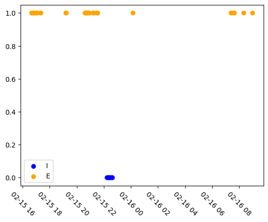

```python
date_min, date_max = pd.to_datetime(np.min(temp_fn_indexing.iloc[:, -2:].values, axis=None)), pd.to_datetime(np.max(temp_fn_indexing.iloc[:, -2:].values, axis=None))
temp_i = temp_fn_indexing.loc[np.where(temp_fn_indexing['IE_TYPE']=='I')[0],:]
temp_e = temp_fn_indexing.loc[np.where(temp_fn_indexing['IE_TYPE']=='E')[0],:]
plt.xticks(rotation=-45)
plt.scatter(temp_i['IN_OUT_TIME_DT2'], np.zeros(len(temp_i)), c='b')
plt.scatter(temp_e['IN_OUT_TIME_DT2'], np.ones(len(temp_e)), c='orange')
plt.legend(['I', 'E'])
```

j=7의 경우 IN_OUT_TIME_DT가 제대로 들어간 값으로 보임

```python
(len(np.where(df_dual_cycling_group['Dual_E_percent']>90.)[0])/len(df_dual_cycling_group)), (len(np.where(df_dual_cycling_group['Dual_I_percent']>90.)[0])/len(df_dual_cycling_group)) # 크게 차이나지 않음
```

```
(0.16205669688970503, 0.21066222885343738)
```

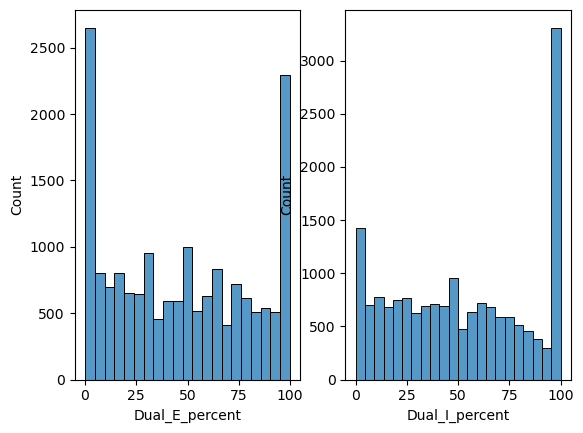

```python
plt.subplot(121)
sns.histplot(df_dual_cycling_group['Dual_E_percent'], label='dual E percent')
plt.subplot(122)
sns.histplot(df_dual_cycling_group['Dual_I_percent'], label='dual I percent')
```

```python
print((np.sum(df_dual_cycling_group['Dual_E_count']) / np.sum(df_dual_cycling_group['E_count'])), (np.sum(df_dual_cycling_group['Dual_I_count']) / np.sum(df_dual_cycling_group['I_count'])))
```

```
0.5479748518768456 0.5532381399846111
```

#### 양적하 동시 작업의 월별 분포 확인

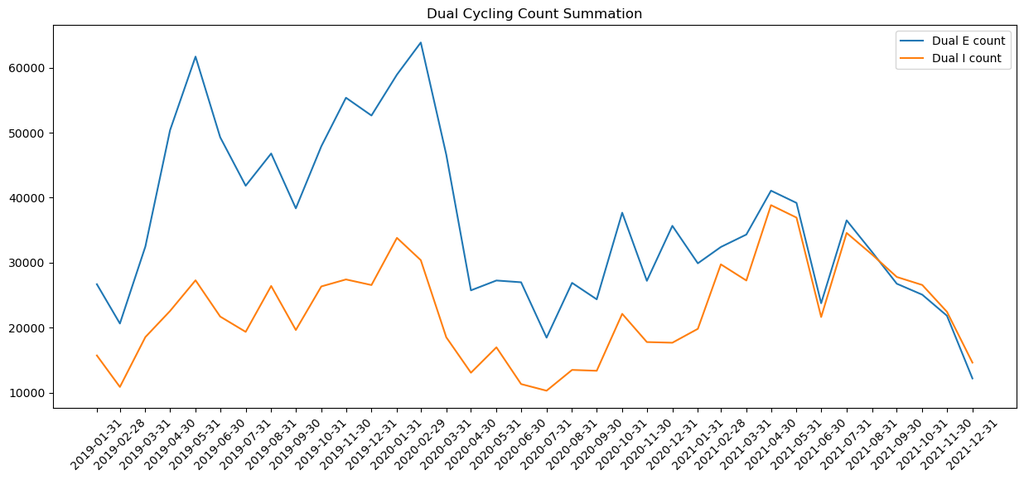

```python
# df_dual_cycling_group2 = deepcopy(df_dual_cycling_group)
# df_dual_cycling_group2['ATA'] = pd.to_datetime(df_dual_cycling_group2['ATA'])
temp_for_resample = df_dual_cycling_group2[['ATA', 'Dual_E_count', 'Dual_I_count']]
temp_for_resample.index = df_dual_cycling_group2['ATA']

dataset_m = temp_for_resample.resample('M')[['Dual_E_count', 'Dual_I_count']].agg(np.sum).fillna(0)

x = dataset_m.index
y = dataset_m
plt.figure(figsize=(15,6))
plt.plot(dataset_m['Dual_E_count'], label='Dual E count')
plt.plot(dataset_m['Dual_I_count'], label='Dual I count')
plt.xticks(x, rotation = 45)
plt.legend()
plt.title('Dual Cycling Count Summation')
plt.show()
```

- 총 count수라 양적하 진행 건마다 규모가 다를 수 있음 -> sum말고 average 적용

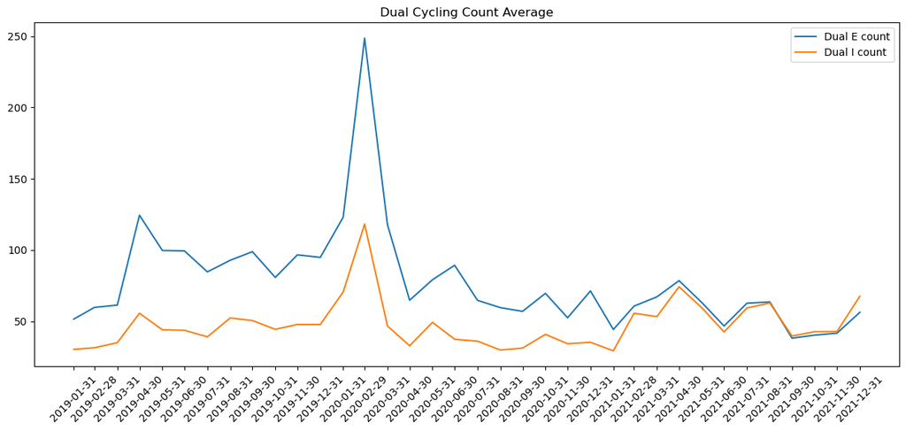

```python
temp_for_resample = df_dual_cycling_group2[['ATA', 'Dual_E_count', 'Dual_I_count']]
temp_for_resample.index = df_dual_cycling_group2['ATA']

dataset_m = temp_for_resample.resample('M')[['Dual_E_count', 'Dual_I_count']].agg(np.average).fillna(0)

x = dataset_m.index
y = dataset_m
plt.figure(figsize=(15,6))
plt.plot(dataset_m['Dual_E_count'], label='Dual E count')
plt.plot(dataset_m['Dual_I_count'], label='Dual I count')
plt.xticks(x, rotation = 45)
plt.legend()
plt.title('Dual Cycling Count Average')
plt.show()
```

```
count    340.000000
mean      51.252941
std       57.862523
min        1.000000
25%        6.000000
50%       34.000000
75%       67.000000
max      317.000000
Name: CALLSIGN, dtype: float64
```

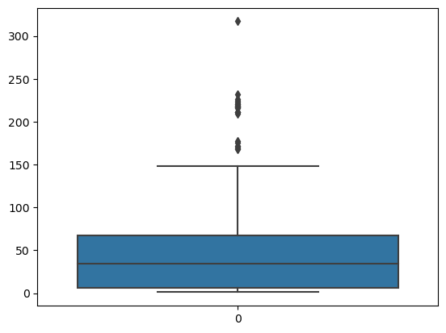

```python
count_dual_by_berth = df_dual_cycling_group.groupby(['TERMINAL', 'PORT_CODE', 'BERTH'], dropna=False)['CALLSIGN'].agg('count')
sns.boxplot(count_dual_by_berth)
print(count_dual_by_berth.describe())
```

```python
count_dual_by_berth2 = count_dual_by_berth.reset_index()
count_dual_by_berth2.columns = ['TERMINAL', 'PORT_CODE', 'BERTH', 'DUAL_COUNT']
count_dual_by_berth2.iloc[np.where(count_dual_by_berth2['DUAL_COUNT'] > 34)[0],:]
```

|  | TERMINAL | PORT_CODE | BERTH | DUAL_COUNT |
| --- | --- | --- | --- | --- |
| 0 | BCTOC | KRPUS | 1A | 133 |
| 1 | BCTOC | KRPUS | 1B | 111 |
| 2 | BCTOC | KRPUS | 1C | 113 |
| 3 | BCTOC | KRPUS | 1D | 65 |
| 6 | BCTOC | KRPUS | 1G | 52 |
| ... | ... | ... | ... | ... |
| 333 | SNCTC | KRINC | 6A | 232 |
| 334 | SNCTC | KRINC | 6B | 222 |
| 335 | SNCTC | KRINC | 7A | 218 |
| 336 | SNCTC | KRINC | 7B | 221 |
| 339 | UDITC | KRUSN | NaN | 169 |

169 rows × 4 columns

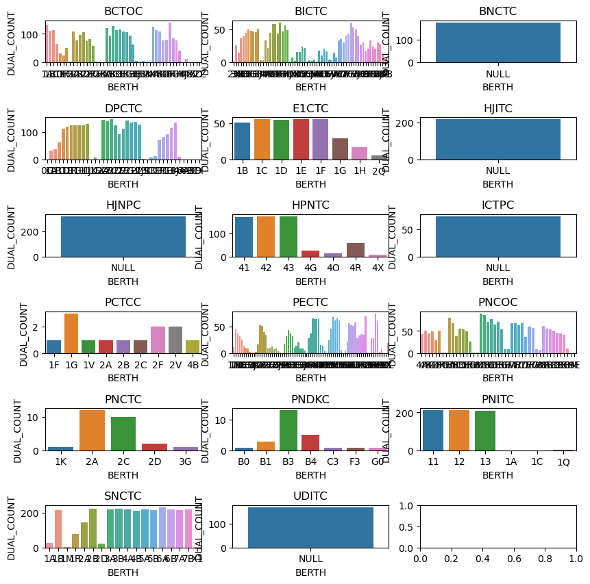

```python
fig, ax = plt.subplots(6,3,figsize=(10, 10))
fig.subplots_adjust(hspace=1.3)

for idx, terminal in enumerate(np.unique(count_dual_by_berth2['TERMINAL'].values)):
    temp_for_graph = count_dual_by_berth2.loc[count_dual_by_berth2['TERMINAL']==terminal]
    ax[idx//3, idx%3].set_title(terminal)
    if (len(temp_for_graph)==1) and (temp_for_graph['BERTH'].isna().sum()==1):
        temp_for_graph['BERTH'] = 'NULL'
        sns.barplot(x='BERTH', y='DUAL_COUNT',data=temp_for_graph, ax=ax[idx//3, idx%3])
    else:
        sns.barplot(x='BERTH', y='DUAL_COUNT',data=temp_for_graph, ax=ax[idx//3, idx%3])
```

선석별로 차이는 나지만 유의한 차이나 그 이유로 볼 수 없는 것 없음

```python
cnt_deovad_tp_by_berth = deovad_tp[['TERMINAL', 'PORT_CODE', 'BERTH', 'CALLSIGN', 'ATA', 'ATD']].drop_duplicates()
cnt_deovad_tp_by_berth
```

|  | TERMINAL | PORT_CODE | BERTH | CALLSIGN | ATA | ATD |
| --- | --- | --- | --- | --- | --- | --- |
| 0 | UDITC | KRUSN | 1G | D7CC | 2019-10-04 08:15:00 | 2019-10-04 15:00:00 |
| 44 | UDITC | KRUSN | 2B | D7CC | 2019-10-04 08:15:00 | 2019-10-04 15:00:00 |
| 50 | UDITC | KRUSN | NaN | D7CC | 2019-10-04 08:15:00 | 2019-10-04 15:00:00 |
| 106 | PCTCC | KRPTK | 2C | V7UX8 | 2019-10-04 21:05:00 | 2019-10-05 05:36:00 |
| 107 | PCTCC | KRPTK | NaN | V7UX8 | 2019-10-04 21:05:00 | 2019-10-05 05:36:00 |
| ... | ... | ... | ... | ... | ... | ... |
| 8020359 | SNCTC | KRINC | 3A | BATI | 2021-11-07 16:20:00 | 2021-11-11 02:23:00 |
| 8020418 | SNCTC | KRINC | 3B | BATI | 2021-11-07 16:20:00 | 2021-11-11 02:23:00 |
| 8020420 | SNCTC | KRINC | 1J | BATI | 2021-11-07 16:20:00 | 2021-11-11 02:23:00 |
| 8020430 | SNCTC | KRINC | 1A | BATI | 2021-11-07 16:20:00 | 2021-11-11 02:23:00 |
| 8020481 | SNCTC | KRINC | 2M | BATI | 2021-11-07 16:20:00 | 2021-11-11 02:23:00 |

165315 rows × 6 columns

```python
temp_for_join = df_dual_cycling_group[['TERMINAL', 'PORT_CODE', 'BERTH', 'CALLSIGN', 'ATA', 'ATD']]
temp_for_join['is_dual'] = 1
percnt_deovad_tp_by_berth = pd.merge(cnt_deovad_tp_by_berth, temp_for_join, how='left')
percnt_deovad_tp_by_berth['is_dual'] = np.where(np.isnan(percnt_deovad_tp_by_berth['is_dual']),0, percnt_deovad_tp_by_berth['is_dual'])
percnt_deovad_tp_by_berth ## 전체 접안건수(양적하가 동시에 일어나지 않은 작업 포함) 중 dual_cycling 일어나면 is_dual==1.0
```

|  | TERMINAL | PORT_CODE | BERTH | CALLSIGN | ATA | ATD | is_dual |
| --- | --- | --- | --- | --- | --- | --- | --- |
| 0 | UDITC | KRUSN | 1G | D7CC | 2019-10-04 08:15:00 | 2019-10-04 15:00:00 | 0.0 |
| 1 | UDITC | KRUSN | 2B | D7CC | 2019-10-04 08:15:00 | 2019-10-04 15:00:00 | 0.0 |
| 2 | UDITC | KRUSN | NaN | D7CC | 2019-10-04 08:15:00 | 2019-10-04 15:00:00 | 0.0 |
| 3 | PCTCC | KRPTK | 2C | V7UX8 | 2019-10-04 21:05:00 | 2019-10-05 05:36:00 | 0.0 |
| 4 | PCTCC | KRPTK | NaN | V7UX8 | 2019-10-04 21:05:00 | 2019-10-05 05:36:00 | 0.0 |
| ... | ... | ... | ... | ... | ... | ... | ... |
| 165310 | SNCTC | KRINC | 3A | BATI | 2021-11-07 16:20:00 | 2021-11-11 02:23:00 | 0.0 |
| 165311 | SNCTC | KRINC | 3B | BATI | 2021-11-07 16:20:00 | 2021-11-11 02:23:00 | 0.0 |
| 165312 | SNCTC | KRINC | 1J | BATI | 2021-11-07 16:20:00 | 2021-11-11 02:23:00 | 0.0 |
| 165313 | SNCTC | KRINC | 1A | BATI | 2021-11-07 16:20:00 | 2021-11-11 02:23:00 | 0.0 |
| 165314 | SNCTC | KRINC | 2M | BATI | 2021-11-07 16:20:00 | 2021-11-11 02:23:00 | 0.0 |

165315 rows × 7 columns

각 접안 건 별로 dual이 일어났는지 표시했음

```python
for_graph = percnt_deovad_tp_by_berth.groupby(['PORT_CODE','TERMINAL'], dropna=False).agg({'is_dual':['sum', 'count']})
for_graph = for_graph.reset_index()
for_graph.columns = ['_'.join(col).rstrip('_') for col in for_graph.columns.values]
for_graph['is_dual_percent'] = (for_graph['is_dual_sum'] / for_graph['is_dual_count'])*100
for_graph
```

|  | PORT_CODE | TERMINAL | is_dual_sum | is_dual_count | is_dual_percent |
| --- | --- | --- | --- | --- | --- |
| 0 | KRINC | E1CTC | 322.0 | 752 | 42.819149 |
| 1 | KRINC | HJITC | 217.0 | 4470 | 4.854586 |
| 2 | KRINC | ICTPC | 74.0 | 1292 | 5.727554 |
| 3 | KRINC | IFPCC | 0.0 | 489 | 0.000000 |
| 4 | KRINC | SNCTC | 2922.0 | 8190 | 35.677656 |
| 5 | KRPTK | PCTCC | 190.0 | 4501 | 4.221284 |
| 6 | KRPTK | PNCTC | 26.0 | 5090 | 0.510806 |
| 7 | KRPUS | BCTOC | 2968.0 | 22560 | 13.156028 |
| 8 | KRPUS | BICTC | 1729.0 | 19328 | 8.945571 |
| 9 | KRPUS | BNCTC | 175.0 | 7170 | 2.440725 |
| 10 | KRPUS | DPCTC | 2867.0 | 12400 | 23.120968 |
| 11 | KRPUS | HJNPC | 317.0 | 6449 | 4.915491 |
| 12 | KRPUS | HPNTC | 614.0 | 1403 | 43.763364 |
| 13 | KRPUS | PECTC | 2069.0 | 57757 | 3.582250 |
| 14 | KRPUS | PNCOC | 2105.0 | 5578 | 37.737540 |
| 15 | KRPUS | PNDKC | 25.0 | 2089 | 1.196745 |
| 16 | KRPUS | PNITC | 637.0 | 1355 | 47.011070 |
| 17 | KRTSN | DDCTC | 0.0 | 27 | 0.000000 |
| 18 | KRUSN | UDITC | 169.0 | 4415 | 3.827860 |

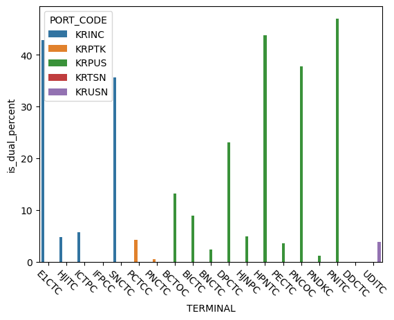

```python
plt.xticks(rotation=-45)
sns.barplot(x='TERMINAL', y='is_dual_percent', hue='PORT_CODE',data=for_graph)
```